# 산업공학특론I_중간고사

나재영 (2024189799)

4/10/2024

### [중간고사 개요]

#### 1. 중간고사 답안 작성 및 제출 요령

- 모든 답안 도출 과정은 R 코드로 작성되어야 하며, 코드에는 분석 과정을 식별할 수 있도록 주석(#)으로 설명이 작성되어야 한다. (R 코드 없이 답만 적는 경우 오답 처리)
- 수강생 간 코드를 공유하거나 동일하게 작성하는 행위를 금지한다. (적발 시 진실의 방 소환 및 모두 0점으로 성적 반영)
- 특정한 문제에 대한 답안은 해당 문항에 대한 코드에 작성되어야 한다. (1번 문항에 대한 답을 2번 문항에 적는 경우 오답 처리)
- 답안은 Rmd 확장자로 보고서 제작이 가능하도록 제출하는 것을 원칙으로 하나, Markdown 실행이 어려운 경우 R 스크립트로 작성하되 채점이 가능하도록 문항 별로 스크립트를 작성하여야 한다.
- 중간고사 답안은 4월 10일 23시 59분까지 온라인 강의실 내 과제 및 평가 - 중간고사 탭에 제출하여야 하며, 4월 11일 자정 이후에는 제출이 불가하다. (이후 다른 경로를 통하여 제출 시 총점의 50%로 성적 반영)

#### 2. 데이터 설명

어느 의류 생산 공정에서는 재봉 (sewing), 마감 (finishing)으로 부서를 구성하여 공정을 운영하고 있으며, 공정의 생산성을 개선하기 위해 일별 공정 작업 관련 데이터를 수집하여 생산성에 영향을 미치는 요인을 분석하고자 한다. 데이터 분석에 활용하는 변수의 정보는 다음과 같다.

- date: 집계 날짜
- quarter: 한 달을 나눈 분기 (주)
- department: 부서
- day: 요일
- team: 부서별 투입 인원 수
- targeted_productivity: 당초에 목표한 생산성 점수
- over_time: 초과근무 (분)
- incentive: 성과급
- actual_productivity: 실제 생산성 점수

상기에 기술된 작성요령과 데이터를 기반으로 주어진 문제에 대한 분석 과정과 그에 따른 답안을 기술하시오.

### [중간고사 문항]

#### 1. 주어진 데이터에서 데이터 탐색 (EDA) 및 전처리를 수행하고, 결과를 시각화하시오. (10점)

- 활용하지 않는 변수 (date, smv, wip, idle_time, idle_men, no_of_style_change, no_of_workers)는 삭제할 것
- 시각화 시 범주형 변수는 막대그래프로, 연속형 변수는 히스토그램으로 표현할 것

```r
# 데이터 불러오기
clth_dat = read.csv('산업공학특론I_중간고사 데이터.csv')

# 데이터 확인
head(clth_dat)
```

```
##       date  quarter department      day team targeted_productivity   smv  wip
## 1 1/1/2015 Quarter1     sweing Thursday    8                  0.80 26.16 1108
## 2 1/1/2015 Quarter1 finishing  Thursday    1                  0.75  3.94   NA
## 3 1/1/2015 Quarter1     sweing Thursday   11                  0.80 11.41  968
## 4 1/1/2015 Quarter1     sweing Thursday   12                  0.80 11.41  968
## 5 1/1/2015 Quarter1     sweing Thursday    6                  0.80 25.90 1170
## 6 1/1/2015 Quarter1     sweing Thursday    7                  0.80 25.90  984
##   over_time incentive idle_time idle_men no_of_style_change no_of_workers
## 1      7080        98         0        0                  0          59.0
## 2       960         0         0        0                  0           8.0
## 3      3660        50         0        0                  0          30.5
## 4      3660        50         0        0                  0          30.5
## 5      1920        50         0        0                  0          56.0
## 6      6720        38         0        0                  0          56.0
##   actual_productivity
## 1           0.9407254
## 2           0.8865000
## 3           0.8005705
## 4           0.8005705
## 5           0.8003819
## 6           0.8001250
```

```r
summary(clth_dat)
```

```
##      date             quarter           department            day
##  Length:1197        Length:1197        Length:1197        Length:1197
##  Class :character   Class :character   Class :character   Class :character
##  Mode  :character   Mode  :character   Mode  :character   Mode  :character
##
##
##
##
##       team        targeted_productivity      smv             wip
##  Min.   : 1.000   Min.   :0.0700        Min.   : 2.90   Min.   :    7.0
##  1st Qu.: 3.000   1st Qu.:0.7000        1st Qu.: 3.94   1st Qu.:  774.5
##  Median : 6.000   Median :0.7500        Median :15.26   Median : 1039.0
##  Mean   : 6.427   Mean   :0.7296        Mean   :15.06   Mean   : 1190.5
##  3rd Qu.: 9.000   3rd Qu.:0.8000        3rd Qu.:24.26   3rd Qu.: 1252.5
##  Max.   :12.000   Max.   :0.8000        Max.   :54.56   Max.   :23122.0
##                                                         NA's   :506
##    over_time       incentive         idle_time           idle_men
##  Min.   :    0   Min.   :   0.00   Min.   :  0.0000   Min.   : 0.0000
##  1st Qu.: 1440   1st Qu.:   0.00   1st Qu.:  0.0000   1st Qu.: 0.0000
##  Median : 3960   Median :   0.00   Median :  0.0000   Median : 0.0000
##  Mean   : 4567   Mean   :  38.21   Mean   :  0.7302   Mean   : 0.3693
##  3rd Qu.: 6960   3rd Qu.:  50.00   3rd Qu.:  0.0000   3rd Qu.: 0.0000
##  Max.   :25920   Max.   :3600.00   Max.   :300.0000   Max.   :45.0000
##
##  no_of_style_change no_of_workers   actual_productivity
##  Min.   :0.0000     Min.   : 2.00   Min.   :0.2337
##  1st Qu.:0.0000     1st Qu.: 9.00   1st Qu.:0.6503
##  Median :0.0000     Median :34.00   Median :0.7733
##  Mean   :0.1504     Mean   :34.61   Mean   :0.7351
##  3rd Qu.:0.0000     3rd Qu.:57.00   3rd Qu.:0.8503
##  Max.   :2.0000     Max.   :89.00   Max.   :1.1204
##
```

```r
# 활용할 변수 및 활용하지 않는 변수 확인
colnames(clth_dat)
```

```
##  [1] "date"                  "quarter"               "department"
##  [4] "day"                   "team"                  "targeted_productivity"
##  [7] "smv"                   "wip"                   "over_time"
## [10] "incentive"             "idle_time"             "idle_men"
## [13] "no_of_style_change"    "no_of_workers"         "actual_productivity"
```

```r
# 활용하지 않는 변수* 삭제
# * [1]date, [7]smv, [8]wip, [11]idle_time, [12]idle_men, [13]no_of_style_change, [14]no_of_workers
delcol = c(1,7,8,11,12,13,14) # 필요 없는 열
clth_dat_pp = clth_dat[-delcol] # 필요 없는 열 삭제

# 전처리 후 데이터 확인
colnames(clth_dat_pp)
```

```
## [1] "quarter"               "department"            "day"
## [4] "team"                  "targeted_productivity" "over_time"
## [7] "incentive"             "actual_productivity"
```

```r
head(clth_dat_pp)
```

```
##    quarter department      day team targeted_productivity over_time incentive
## 1 Quarter1     sweing Thursday    8                  0.80      7080        98
## 2 Quarter1 finishing  Thursday    1                  0.75       960         0
## 3 Quarter1     sweing Thursday   11                  0.80      3660        50
## 4 Quarter1     sweing Thursday   12                  0.80      3660        50
## 5 Quarter1     sweing Thursday    6                  0.80      1920        50
## 6 Quarter1     sweing Thursday    7                  0.80      6720        38
##   actual_productivity
## 1           0.9407254
## 2           0.8865000
## 3           0.8005705
## 4           0.8005705
## 5           0.8003819
## 6           0.8001250
```

```r
summary(clth_dat_pp)
```

```
##    quarter           department            day                 team
##  Length:1197        Length:1197        Length:1197        Min.   : 1.000
##  Class :character   Class :character   Class :character   1st Qu.: 3.000
##  Mode  :character   Mode  :character   Mode  :character   Median : 6.000
##                                                           Mean   : 6.427
##                                                           3rd Qu.: 9.000
##                                                           Max.   :12.000
##  targeted_productivity   over_time       incentive       actual_productivity
##  Min.   :0.0700        Min.   :    0   Min.   :   0.00   Min.   :0.2337
##  1st Qu.:0.7000        1st Qu.: 1440   1st Qu.:   0.00   1st Qu.:0.6503
##  Median :0.7500        Median : 3960   Median :   0.00   Median :0.7733
##  Mean   :0.7296        Mean   : 4567   Mean   :  38.21   Mean   :0.7351
##  3rd Qu.:0.8000        3rd Qu.: 6960   3rd Qu.:  50.00   3rd Qu.:0.8503
##  Max.   :0.8000        Max.   :25920   Max.   :3600.00   Max.   :1.1204
```

```r
# 각 열의 카테고리 수 확인
{
  for(i in 1:ncol(clth_dat_pp)){
    print(c(colnames(clth_dat_pp[i]), length(table(clth_dat_pp[i]))))
  }
  print(c('data length',nrow(clth_dat_pp)))
}
```

```
## [1] "quarter" "5"
## [1] "department" "3"
## [1] "day" "6"
## [1] "team" "12"
## [1] "targeted_productivity" "9"
## [1] "over_time" "143"
## [1] "incentive" "48"
## [1] "actual_productivity" "879"
## [1] "data length" "1197"
```

```r
# department의 'finishing'과 'finishing '을 하나로 묶음
c = clth_dat_pp$department
c = gsub(pattern = 'finishing ', replacement = 'finishing', c)
print(table(c))
```

```
## c
## finishing    sweing
##       506       691
```

```r
clth_dat_pp$department = c

# 데이터가 범주형 변수인지 확인
# * [1]quarter, [2]department, [3]day, [4]team, [5]targeted_productivity

for(i in 1:5){
  print(table(clth_dat_pp[i]))
}
```

```
## quarter
## Quarter1 Quarter2 Quarter3 Quarter4 Quarter5
##      360      335      210      248       44
## department
## finishing    sweing
##       506       691
## day
##    Monday  Saturday    Sunday  Thursday   Tuesday Wednesday
##       199       187       203       199       201       208
## team
##   1   2   3   4   5   6   7   8   9  10  11  12
## 105 109  95 105  93  94  96 109 104 100  88  99
## targeted_productivity
## 0.07 0.35  0.4  0.5  0.6 0.65  0.7 0.75  0.8
##    1   27    2   49   57   63  242  216  540
```

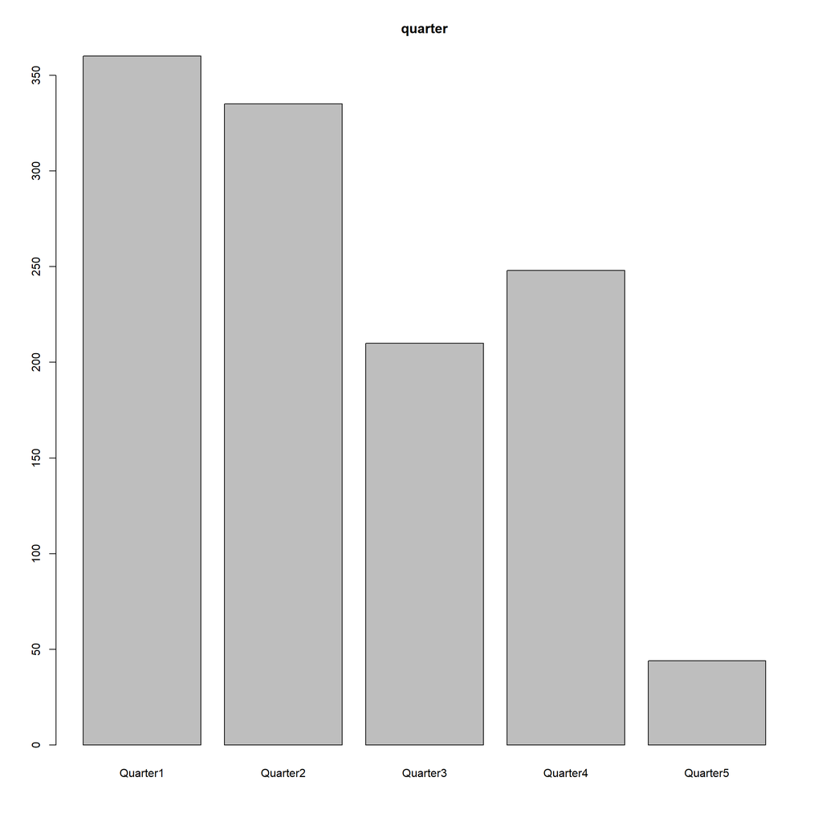

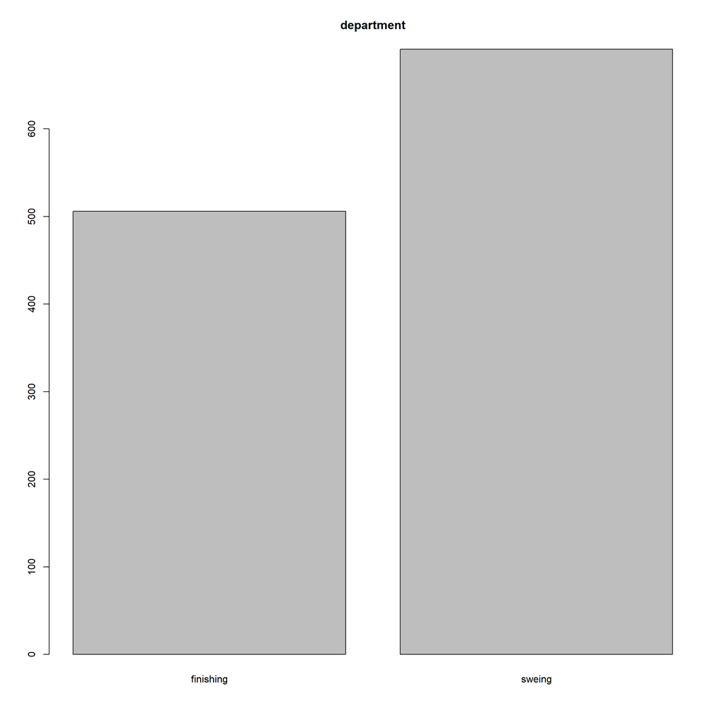

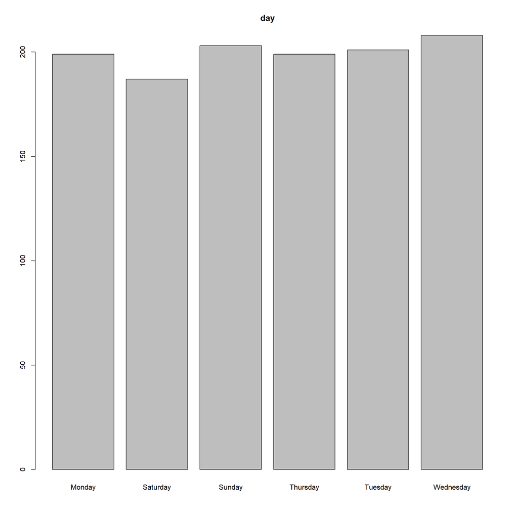

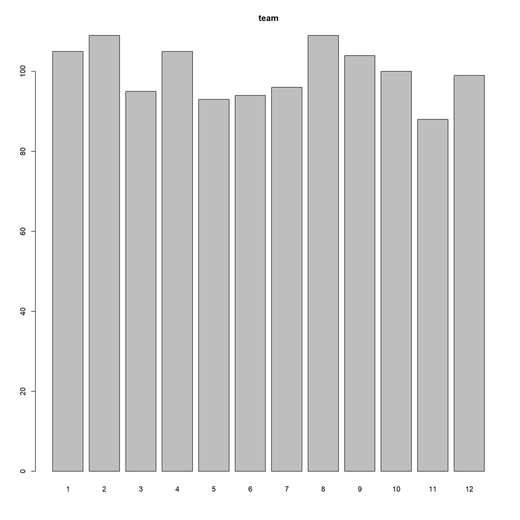

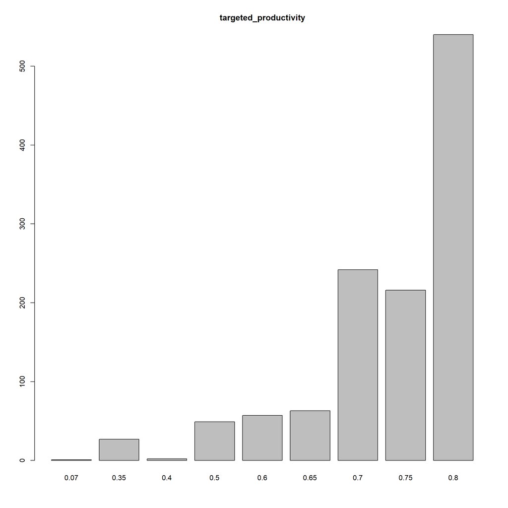

```r
# 범주형 변수(1~5)에 대한 시각화 (막대그래프)

for(i in 1:5){
  barplot(table(clth_dat_pp[i]),main = colnames(clth_dat_pp[i]))
}
```

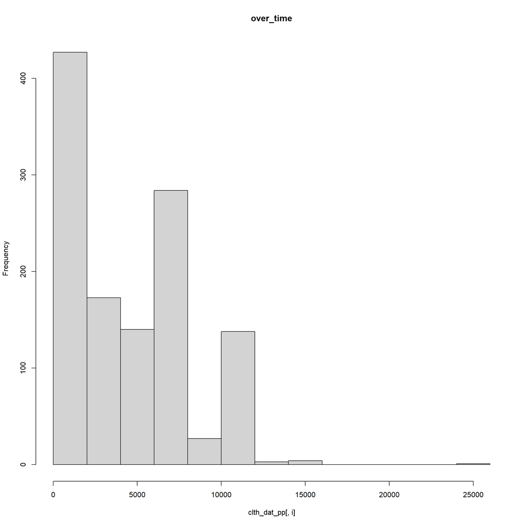

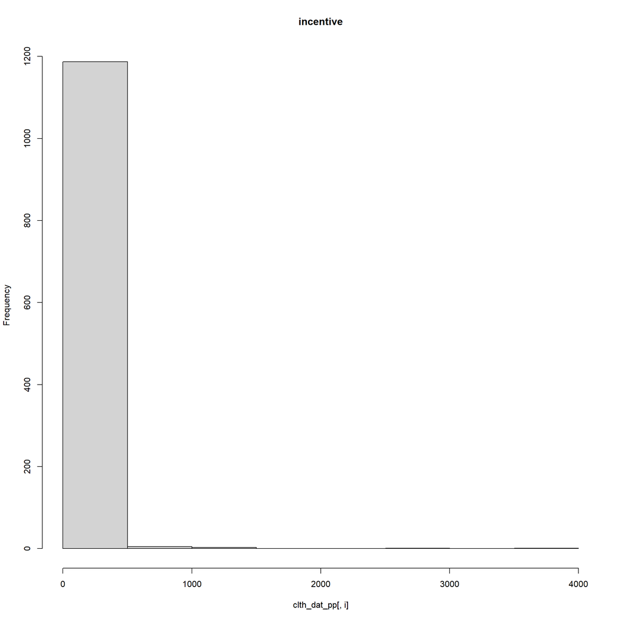

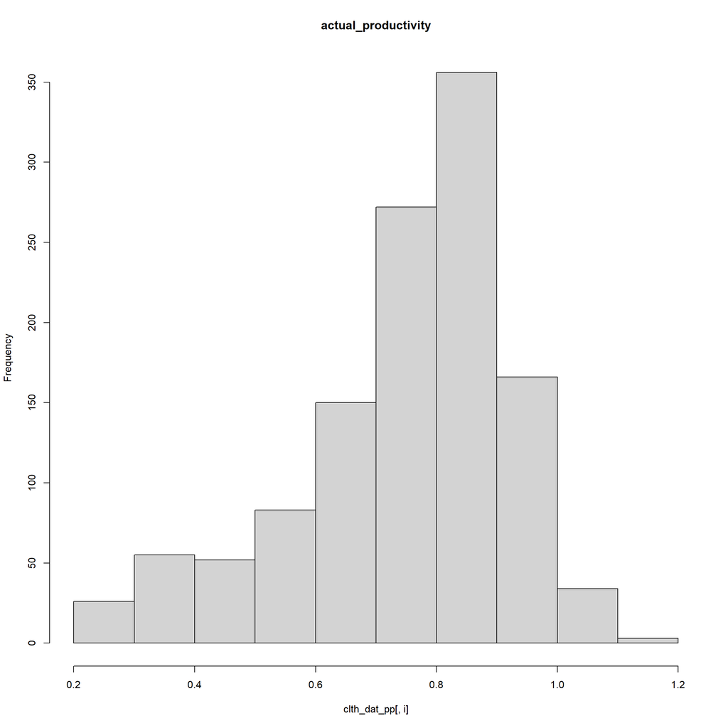

```r
# 연속형 변수(6~8)에 대한 시각화 (히스토그램)

for(i in 6:8){
  hist(clth_dat_pp[,i], main = colnames(clth_dat_pp[i]))
}
```

```r
# head(sort(clth_dat_pp$incentive, decreasing = T), n=50)
```

#### 2. 실제 생산성 점수 (actual_productivity)가 어떠한 분포를 따르는지 규명하기 위하여 여러 분포에 대한 MLE를 추정 및 비교하고, 최적 분포를 도출하시오. (15점)

- 여러 분포 (최소 2개 이상)에 대하여 MLE를 통하여 모수를 추정할 것
- 분포별 추정 결과 비교 시 적합도 평가 지표를 활용할 것
- 추정 결과에 따른 최적 분포를 도출하고, 그 근거를 제시할 것

```r
# 사용할 데이터 추출

dat = clth_dat_pp$actual_productivity

# MLE(최대우도법)를 위한 분포별 로그우도함수(log-likelihood function) 및 계산
??fitdist
```

```
## httpd 도움말 서버를 시작합니다 ... 완료
```

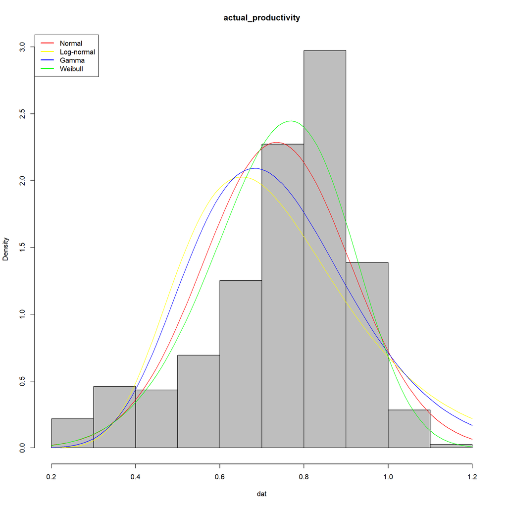

[figure not shown]

```r
# Normal Distribution 가정 및 모수 추정

mlen = function(prm){
  -sum(dnorm(dat, mean = prm[1], sd = prm[2], log = TRUE))
}

optn = optim(c(mean(dat),sd(dat)), mlen)

# Log-normal Distribution 가정 및 모수 추정

mleln = function(prm){
  -sum(dlnorm(dat, meanlog = prm[1], sdlog = prm[2], log = TRUE))
}

optln = optim(c(mean(log(dat)),sd(log(dat))), mleln)


# Gamma Distribution 가정 및 모수 추정

mleg = function(prm){
  -sum(dgamma(dat, shape = prm[1], rate = prm[2], log = TRUE))
}

optg = optim(c(1,1), mleg)


# Weibull Distribution 가정 및 모수 추정

mlew = function(prm){
  -sum(dweibull(dat, shape = prm[1], scale = prm[2], log = TRUE))
}

optw = optim(c(1,1), mlew)


# 각 분포 시각화

{
hist(dat, col='grey', main = 'actual_productivity',prob = T)
curve(dnorm(x, mean = optn$par[1], sd = optn$par[2]), col='red', add = TRUE)
curve(dlnorm(x, meanlog = optln$par[1], sdlog = optln$par[2]), col='yellow', add = TRUE)
curve(dgamma(x, shape = optg$par[1], rate = optg$par[2]), col='blue', add = TRUE)
curve(dweibull(x, shape = optw$par[1], scale = optw$par[2]), col='green', add = TRUE)
legend('topleft',legend = c('Normal','Log-normal','Gamma','Weibull'), col=c('red','yellow','blue','green'), lty = 1, lwd = 2)

plot(ecdf(dat), col='grey', main = 'CDF')
curve(pnorm(x, mean = optn$par[1], sd = optn$par[2]), col='red', lwd = 2, add = TRUE)
curve(plnorm(x, meanlog = optln$par[1], sdlog = optln$par[2]), col='yellow', lwd = 2, add = TRUE)
curve(pgamma(x, shape = optg$par[1], rate = optg$par[2]), col='blue', lwd = 2, add = TRUE)
curve(pweibull(x, shape = optw$par[1], scale = optw$par[2]), col='green', lwd = 2, add = TRUE)
legend('topleft',legend = c('Actual Productivity','Simulated'), col=c('red','green'), lty = 1, lwd = 2)
}
```

```r
# 각 분포별 최대우도값 비교

print(c(-optn$value, -optln$value, -optg$value, -optw$value))
```

```
## [1] 391.8729 198.0136 277.6973 437.8622
```

```r
# 각 분포별 적합도 평가를 위한 AIC, BIC 비교

AICn = -2*-mlen(optn$par)+2*length(optn$par)
AICln = -2*-mleln(optln$par)+2*length(optln$par)
AICg = -2*-mleg(optg$par)+2*length(optg$par)
AICw = -2*-mlew(optw$par)+2*length(optw$par)

print(c(AICn, AICln, AICg, AICw))
```

```
## [1] -779.7458 -392.0272 -551.3947 -871.7245
```

```r
BICn = -2*-mlen(optn$par)+2*length(optn$par)*log(length(dat))
BICln = -2*-mleln(optln$par)+2*length(optln$par)*log(length(dat))
BICg = -2*-mleg(optg$par)+2*length(optg$par)*log(length(dat))
BICw = -2*-mlew(optw$par)+2*length(optw$par)*log(length(dat))

print(c(BICn, BICln, BICg, BICw))
```

```
## [1] -755.3955 -367.6769 -527.0444 -847.3742
```

```r
# 최대 우도값이 가장 높으며, AIC & BIC 값이 가장 작은 Weibull 분포를 최적 분포로 선정

# Weibull 분포가 왼쪽으로 긴 꼬리(Left-Skewed, 왜도값이 음수)를 가진 실 데이터의 형태를 가장 잘 나타냄
```

#### 3. 2. 에서 도출된 최적 분포를 기준으로 MLE 추정 결과를 시각화하고 이를 해석하시오. (10점)

- 시각화의 경우 실제 데이터의 분포와 MLE를 모수로 가지는 분포의 비교가 가능하도록 도시할 것
- 단순 도시가 아닌 도시 결과에 대한 해석 결과를 설명하고, 결론을 도출할 것

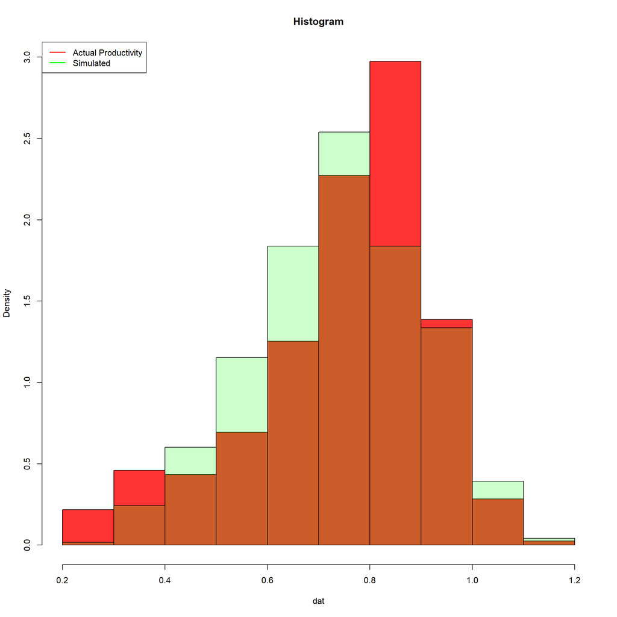

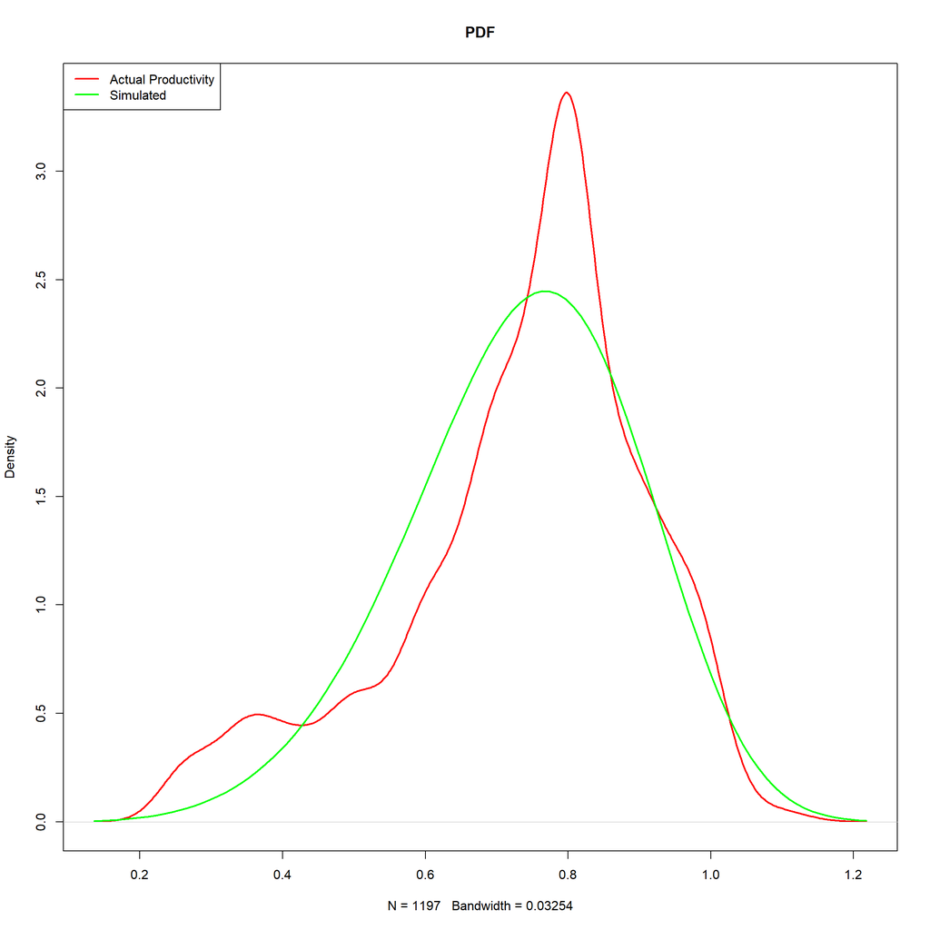

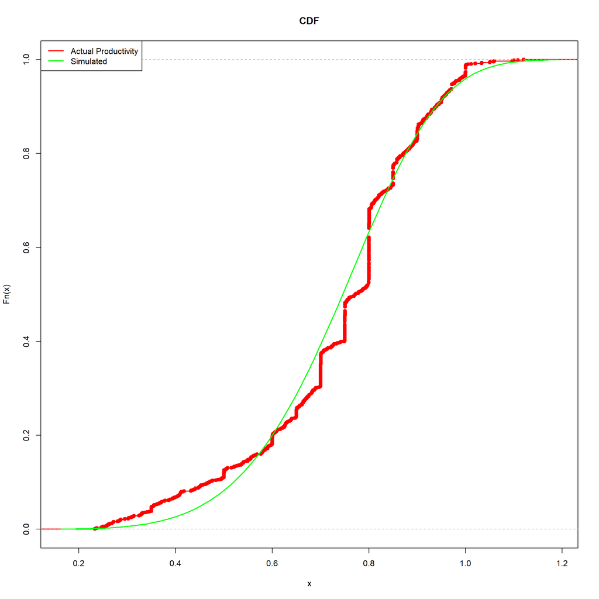

```r
# 와이블 분포 시뮬레이션 (원 데이터와 동일한 n수)

simul_actprod = rweibull(n = length(dat), shape = optw$par[1], scale = optw$par[2])

# 최적 분포 시뮬레이션 결과와 원 데이터 비교 (시각화)

{
hist(dat, col = adjustcolor('red', alpha = 0.8), main = 'Histogram', prob = T)
hist(simul_actprod, col = adjustcolor('green', alpha = 0.2), prob = T, add = TRUE)
legend('topleft',legend = c('Actual Productivity','Simulated'), col=c('red','green'), lty = 1, lwd = 2)

plot(density(dat), col='red', main = 'PDF', lwd = 2)
curve(dweibull(x, shape = optw$par[1], scale = optw$par[2]), col='green', lwd = 2, add = TRUE)
legend('topleft',legend = c('Actual Productivity','Simulated'), col=c('red','green'), lty = 1, lwd = 2)

plot(ecdf(dat), col='red', main = 'CDF', lwd = 2)
curve(pweibull(x, shape = optw$par[1], scale = optw$par[2]), col='green', lwd = 2, add = TRUE)
legend('topleft',legend = c('Actual Productivity','Simulated'), col=c('red','green'), lty = 1, lwd = 2)
}
```

```r
### 도시 결과 해석 ###
# 실제 생산성 점수(actual_productivity)가 0.9를 넘는 높은 값은 와이블 분포의 모델링과 유사함 (pdf & cdf fitness)
# 실제 분포의 생산성이 낮은 경우(0.4~0.7)가 추정 분포보다 적게 나타남
# 반대로 매우 낮은 경우(0~0.4)와 평시(0.8)는 추정 분포보다 많게 나타남

# 이는 다음과 같은 유사성으로 인해 실제 생산성 점수(actual_productivity)의 분포는 평균 점수가 높은 시험의 점수 분포와 유사할 것으로 생각됨
# 1. 상방 한계가 존재하며, 평균값이 Range의 중간보다 윗쪽에 치우침(Left-Skewed)
# 2. 일부 시험을 포기하고 찍은 사람들이 있으며 비슷하게 낮은 점수를 얻으므로 왼쪽꼬리가 길고 두꺼움
# 위 현상을 잘 나타낼 수 있는 분포가 있다면, 시간관련 분포인 Weibull 분포보다 더욱 정확한 모델링을 할 수 있을것으로 생각 됨
```